# ggplot2 Coding Club ANSWERS

## Advanced exercises

### Dataset 1: rescues of animals in London by the firebrigade***

```r
# Some data cleaning first
rescues = read_xlsx("./animal_rescues_UK.xlsx")
rescues$time = as.Date(rescues$date_time_of_call, format = "%d/%m/%Y %H:%M")
rescues$time_char = as.character(rescues$time)
rescues_tidy = rescues %>% separate(time_char, sep = "-", into = c("year", "month", "day")) %>%
  dplyr::select(-c(1, 13, 14))
head(rescues)
```

```
## # A tibble: 6 × 12
##   date_time_of_call type_of_incident animal_group_parent           originof_call
##   <chr>             <chr>            <chr>                         <chr>
## 1 01/01/2009 03:01  Special Service  Dog                           Person (land…
## 2 01/01/2009 08:51  Special Service  Fox                           Person (land…
## 3 04/01/2009 10:07  Special Service  Dog                           Person (mobi…
## 4 05/01/2009 12:27  Special Service  Horse                         Person (mobi…
## 5 06/01/2009 15:23  Special Service  Rabbit                        Person (mobi…
## 6 06/01/2009 19:30  Special Service  Unknown - Heavy Livestock An… Person (land…
## # ℹ 8 more variables: property_type <chr>, property_Category <chr>, ward <chr>,
## #   easting_rounded <dbl>, northing_rounded <dbl>, borough <chr>, time <date>,
## #   time_char <chr>
```

**Try to VISUALIZE the answers to the following questions:**

#### 1.1 In what years do we find the most rescues for dogs, cats and foxes and deer?

- point + line plot (x = time, y = number of rescues)
- faceting per animal

FANCY EXTRAS - with a font - personalized color palette, for every animal

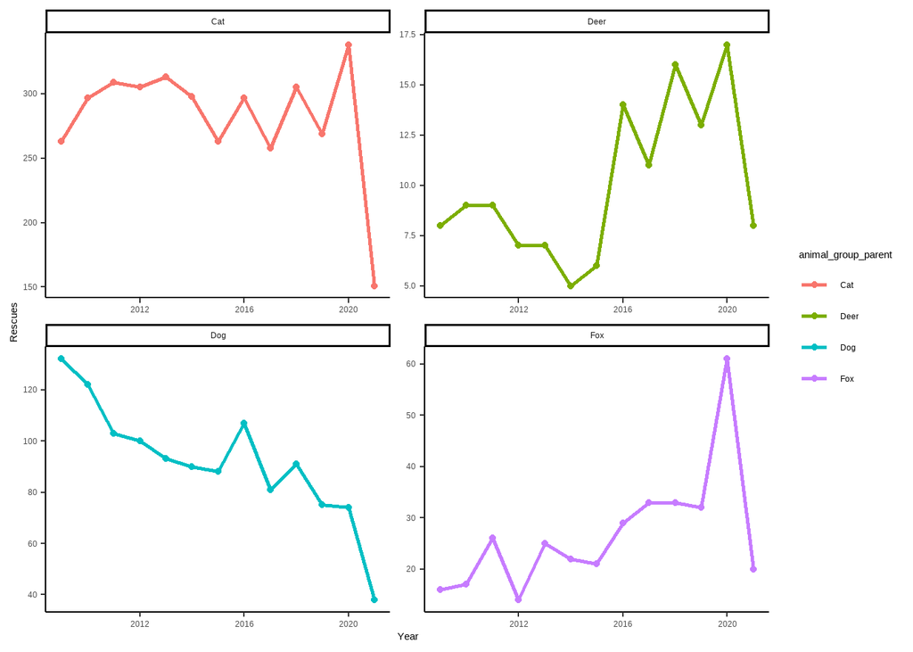

```r
# first some tidying, extracting only the data of the animals that we want
rescues_number = rescues_tidy %>% filter(animal_group_parent == "Cat" | animal_group_parent == "Dog" | animal_group_parent == "Deer" | animal_group_parent == "Fox") %>%
  group_by(year, animal_group_parent) %>% # counting the number of rescues per animal
  summarise(Rescues = n())

#basic solution
plot1_1<-ggplot(rescues_number, aes(x = as.numeric(year), y = Rescues, color = animal_group_parent)) +
  geom_point() +
  geom_line(size = 1) +
  labs(x = "Year") +
  facet_wrap(~animal_group_parent, scales = "free") +
  theme_classic()
plot1_1
```

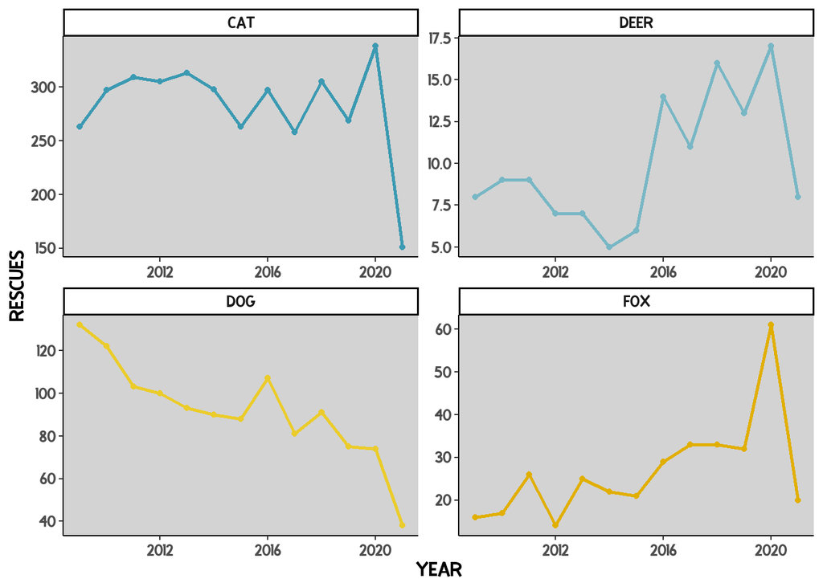

```r
#fancy solution
plot1_1_fancy<-plot1_1 +
  theme(text = element_text(family = "ggfont", size = 30),
        plot.background = element_rect(fill = "white"), panel.background = element_rect(fill = "lightgrey"),
        legend.position="none") +
  scale_color_manual(values = wes_palette("Zissou1", 4, type = "discrete"))
plot1_1_fancy
```

#### 1.2 When do most rescues take place during the year? Is this different for domestic animals (cat, dog) vs. wildlife (deer, fox)?

- density plot (density of rescues for every animal throughout the year)

FANCY EXTRA - with a font - personalized color palette, for every animal - gganimate: show one density plot at the time and switch the species every two seconds

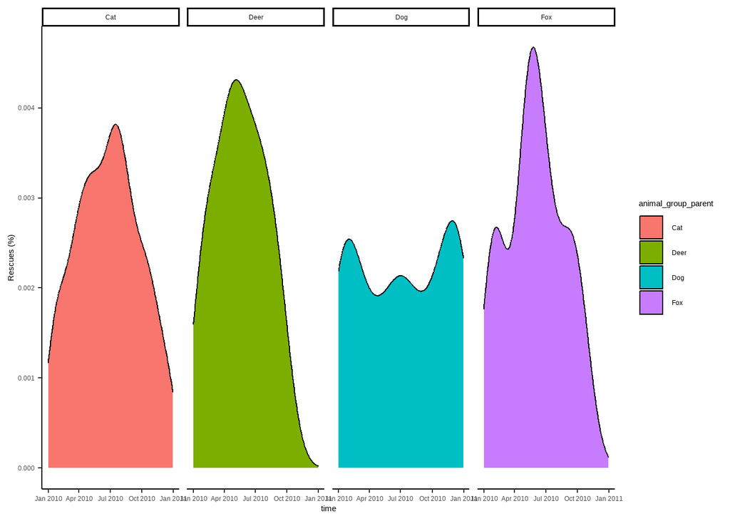

```r
rescues_2010 = rescues_tidy %>%
  filter(year == 2010) %>%
  filter(animal_group_parent == "Cat" | animal_group_parent == "Dog" | animal_group_parent == "Deer" | animal_group_parent == "Fox")

#basic solution
plot1_2<-ggplot(rescues_2010, aes(x = time, fill =  animal_group_parent)) +
  geom_density() +
  theme_classic() +
  labs(y = "Rescues (%)")
plot1_2 + facet_grid(~animal_group_parent)
```

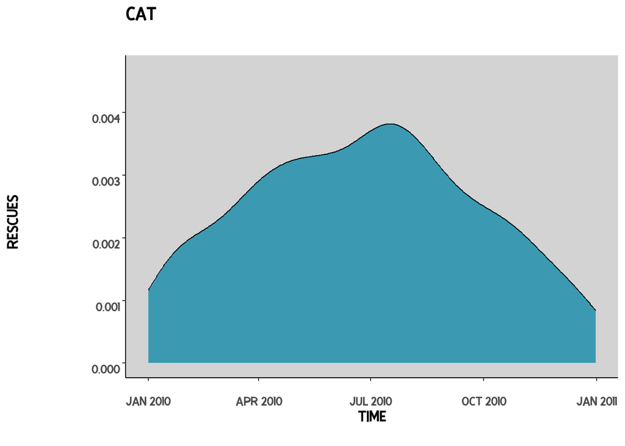

```r
# fancy solution
plot1_2_fancy<-plot1_2+
  theme(text = element_text(family = "ggfont", color = "black", size = 30), legend.position = "none",
        plot.background = element_rect(fill = "white"), panel.background = element_rect(fill = "lightgrey")) +
  scale_fill_manual(values = wes_palette("Zissou1", 4, type = "discrete")) +
  transition_states(animal_group_parent,
                    transition_length = 2,
                    state_length = 1) + ease_aes('cubic-in-out') + ggtitle("{closest_state}")
plot1_2_fancy
```

```r
# anim <- animate(plot1_2_fancy, width = 800, height = 600, fps = 10, duration = 10, renderer = gifski_renderer())
# anim_save("plot1_2_fancy.gif", animation = anim)
```

#### 1.3 What is the proportion of rescues of cats, dogs, horses, birds, foxes, deer, throughout the years? Does this change?

- stream graph

FANCY EXTRAS - with a font - personalized color palette, for every animal

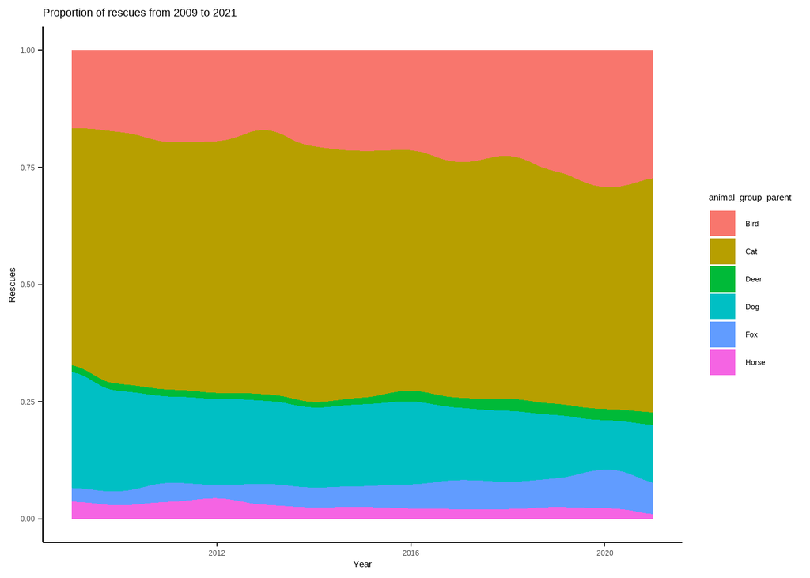

```r
rescues_dist =  rescues_tidy %>%
  filter(!grepl("Unknown", animal_group_parent)) %>%
  filter(animal_group_parent == "Cat" | animal_group_parent == "Dog" | animal_group_parent == "Bird" | animal_group_parent == "Fox" | animal_group_parent == "Deer" | animal_group_parent == "Horse") %>%
  group_by(year, animal_group_parent) %>%
  summarise(Rescues = n())

#basic solution
plot1_3<-ggplot(rescues_dist, aes(x = as.numeric(year), y = Rescues, fill = animal_group_parent)) +
  geom_stream(type = "proportional") +
  labs(x = "Year", title = "Proportion of rescues from 2009 to 2021") +
  theme_classic()
plot1_3
```

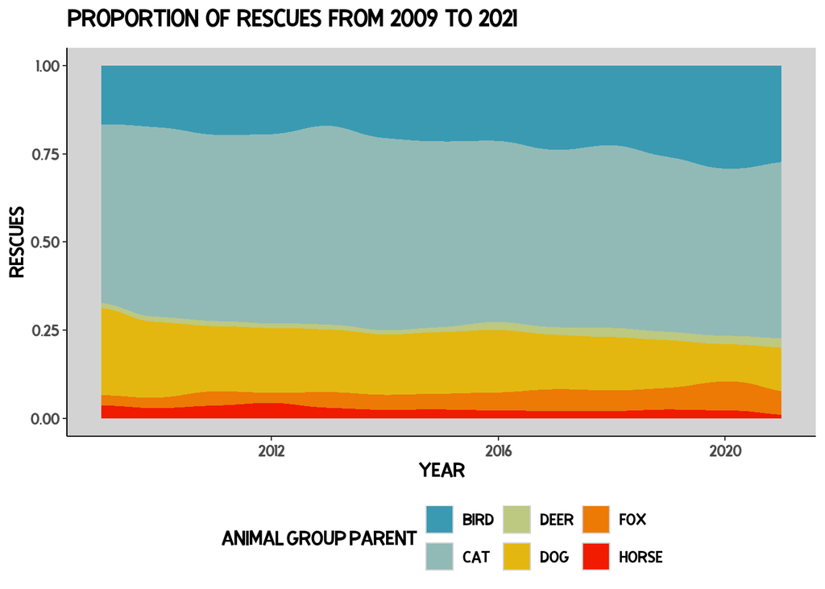

```r
#fancy solution
pal = wes_palette("Zissou1", length(unique(rescues_dist$animal_group_parent)), type = "continuous")
plot1_3_fancy<-plot1_3+
  theme(text = element_text(family = "ggfont", color = "black", size = 30), legend.position = "bottom",
        plot.background = element_rect(fill = "white"), panel.background = element_rect(fill = "lightgrey")) +
  scale_fill_manual(values = pal)
plot1_3_fancy
```

#### 1.4 In what area in London do we find the most rescues for cats?

- bar plot, with labels

FANCY EXTRAS - with a font - personalized color palette, for every animal

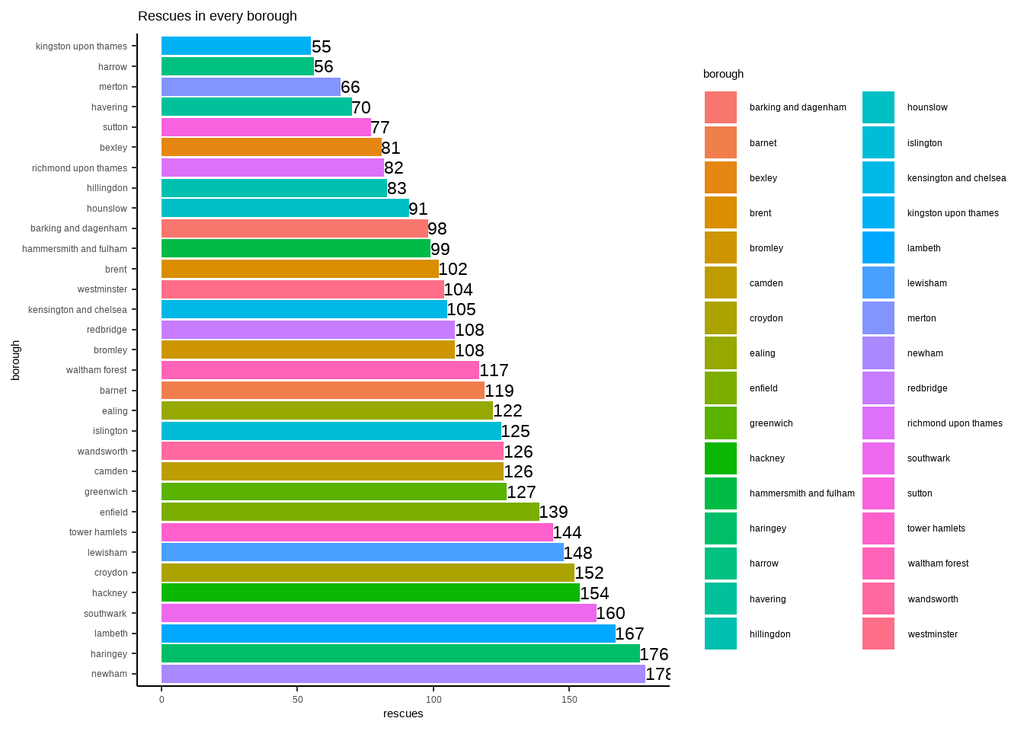

```r
rescues_cat = rescues_tidy %>%
  filter(animal_group_parent == "Cat") %>%
  group_by(borough) %>%
  summarise(Rescues = n())

# basic solution
plot1_4<-ggplot(na.omit(rescues_cat), aes(x = reorder(borough, -Rescues), y = Rescues, fill = borough)) +
  geom_bar(stat = "identity") +
  geom_text(aes(label = Rescues), hjust=0.0, size = 6) +
  labs(x = "borough", y = "rescues", title = "Rescues in every borough") +
  theme_classic()+
  coord_flip()
plot1_4
```

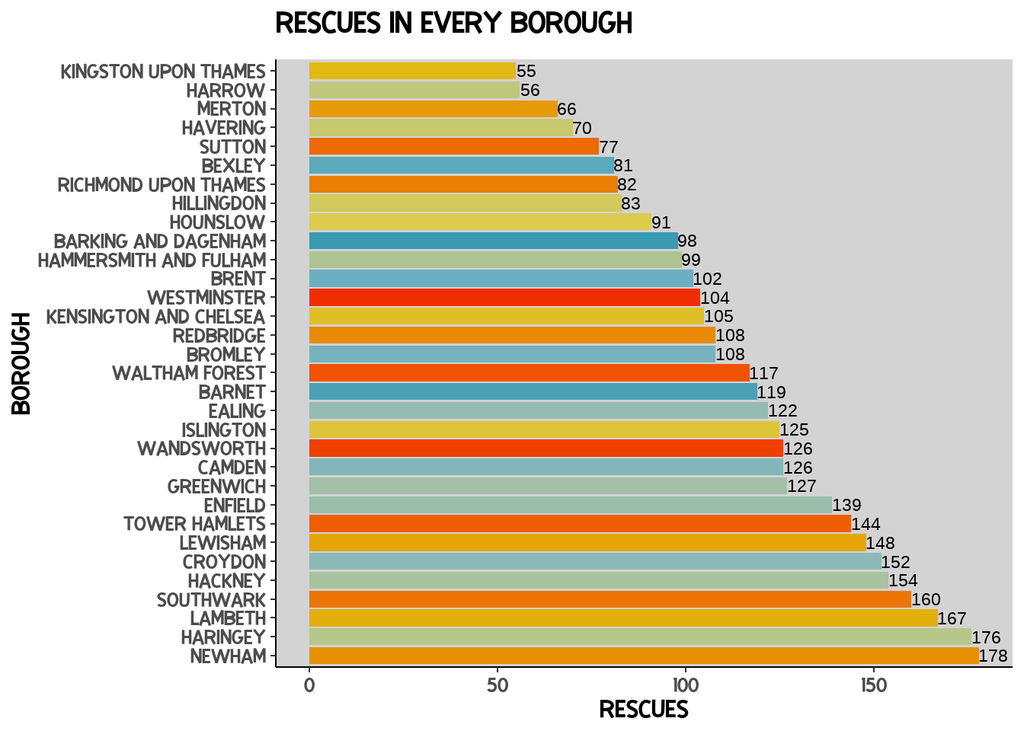

```r
# fancy solution
pal = wes_palette("Zissou1", length(unique(rescues_cat$borough)), type = "continuous")

plot1_4_fancy<-plot1_4 +
  theme(text = element_text(family = "ggfont", color = "black", size = 30), legend.position = "none",
        plot.background = element_rect(fill = "white"), panel.background = element_rect(fill = "lightgrey")) +
  scale_fill_manual(values = pal)
plot1_4_fancy
```

### Dataset 2: Penguins

```r
penguins = read_xlsx("./penguins.xlsx")
head(penguins)
```

```
## # A tibble: 6 × 8
##   species island    bill_length_mm bill_depth_mm flipper_length_mm body_mass_g
##   <chr>   <chr>              <dbl>         <dbl>             <dbl>       <dbl>
## 1 Adelie  Torgersen           39.1          18.7               181        3750
## 2 Adelie  Torgersen           39.5          17.4               186        3800
## 3 Adelie  Torgersen           40.3          18                 195        3250
## 4 Adelie  Torgersen           NA            NA                  NA          NA
## 5 Adelie  Torgersen           36.7          19.3               193        3450
## 6 Adelie  Torgersen           39.3          20.6               190        3650
## # ℹ 2 more variables: sex <chr>, year <dbl>
```

**Try to VISUALIZE the answers to the following questions**

#### 2.1 What are the distributions of the morphological traits? (violin plot)

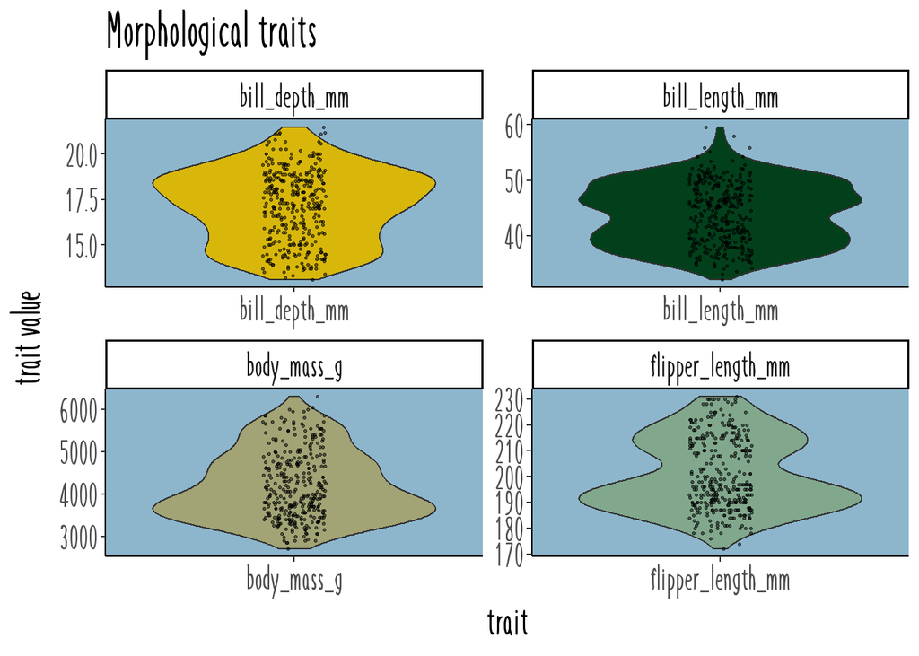

```r
penguins_long = penguins %>%
  pivot_longer(cols = c("bill_length_mm", "bill_depth_mm", "flipper_length_mm", "body_mass_g"), names_to = "trait", values_to = "trait_value")

ggplot(penguins_long, aes(x = trait, y  = trait_value, fill = trait)) +
  #geom_boxplot() +
  geom_violin() +
  geom_jitter(size = 0.5, alpha = 0.5, height = 0, width = 0.1) +
  theme_classic() +
  facet_wrap(~trait, scales = "free") +
  theme(text = element_text(family = "penguin", size = 40), legend.position = "none",
        plot.background = element_rect(fill = "white"), panel.background = element_rect(fill = "lightskyblue3")) +
  labs(y = "trait value", title = "Morphological traits") +
  scale_fill_manual(values = wes_palette("Cavalcanti1", 4, type = "discrete"))
```

#### 2.2 Are there relationships between the morphological traits? And is there a sex difference? (point graph, with linear regression line)

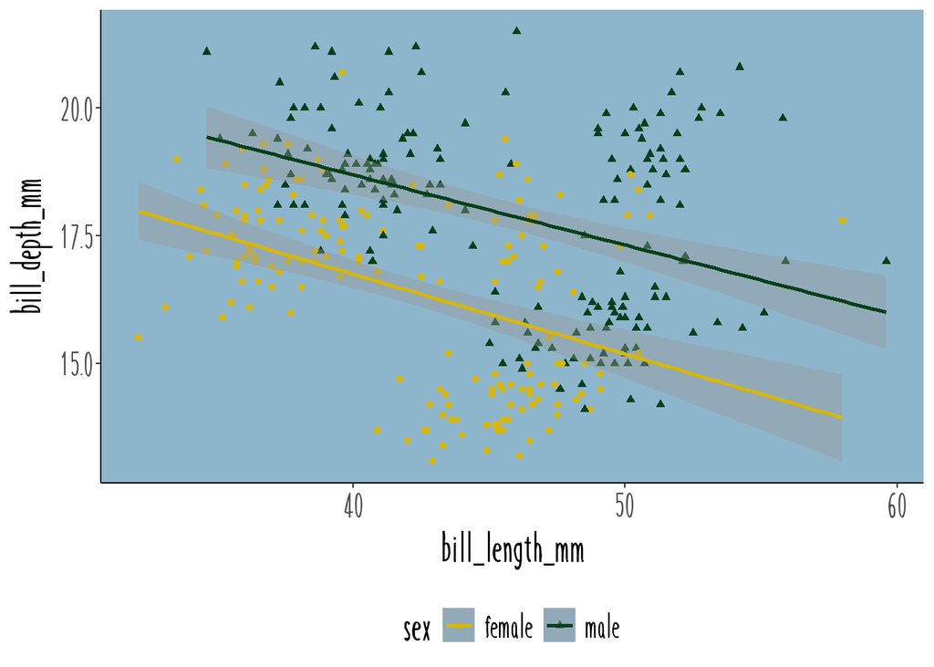

```r
penguins_sex = penguins %>% filter(sex == "male" | sex == "female")
ggplot(penguins_sex, aes(x = bill_length_mm, y = bill_depth_mm, color = sex, shape = sex)) +
  geom_point() +
  geom_smooth(method = "lm", aes(group = sex)) +
  theme_classic() +
  theme(text = element_text(family = "penguin", size = 40), legend.position = "bottom",
        plot.background = element_rect(fill = "white"), panel.background = element_rect(fill = "lightskyblue3")) +
  labs() +
  scale_color_manual(values = wes_palette("Cavalcanti1", 2, type = "discrete"))
```

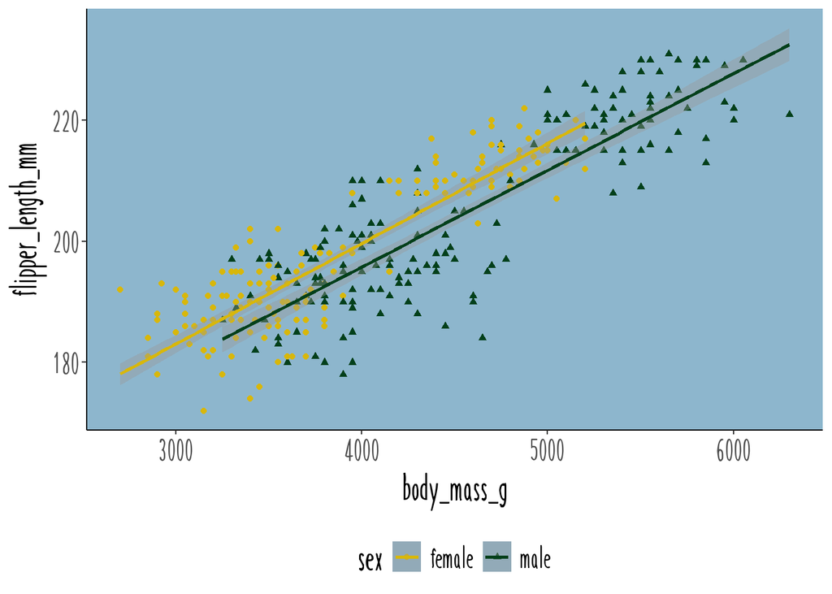

```r
ggplot(penguins_sex, aes(y = flipper_length_mm, x = body_mass_g, color = sex, shape = sex)) +
  geom_point() +
  geom_smooth(method = "lm", aes(group = sex)) +
  theme_classic() +
  theme(text = element_text(family = "penguin", size = 40), legend.position = "bottom",
        plot.background = element_rect(fill = "white"), panel.background = element_rect(fill = "lightskyblue3")) +
  labs() +
  scale_color_manual(values = wes_palette("Cavalcanti1", 2, type = "discrete"))
```

#### 2.3 How do the species differ in body weight? Is there a sex effect? (box plot, 2 factors)

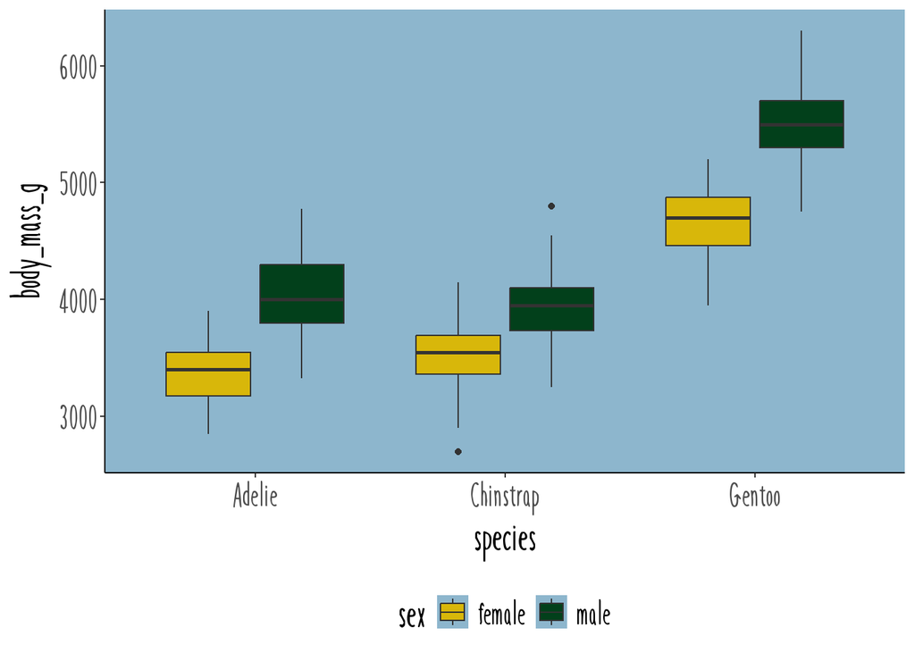

```r
ggplot(penguins_sex, aes(x = species, y = body_mass_g, fill = sex)) +
  geom_boxplot() +
  theme_classic() +
  theme(text = element_text(family = "penguin", size = 40), legend.position = "bottom",
        plot.background = element_rect(fill = "white"), panel.background = element_rect(fill = "lightskyblue3")) +
  scale_fill_manual(values = wes_palette("Cavalcanti1", 2, type = "discrete"))
```

#### 2.4 Did the body weight change over the years? Is there a difference between species? (boxplot, facet)

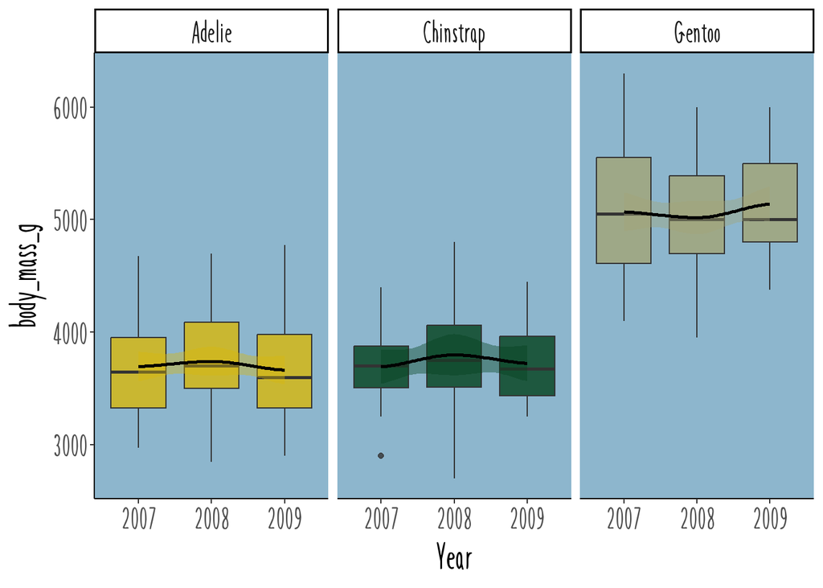

```r
ggplot(penguins, aes(x = as.factor(year), y = body_mass_g, fill = species)) +
  geom_boxplot( alpha = 0.8) +
  facet_wrap(~species) +
  theme_classic() +
  scale_fill_manual(values = wes_palette("Cavalcanti1", 3, type = "discrete")) +
  geom_smooth(aes(group = species), color = "black", se = T) +
  labs(x = "Year") +
  theme(text = element_text(family = "penguin", size = 40), legend.position = "none",
        plot.background = element_rect(fill = "white"), panel.background = element_rect(fill = "lightskyblue3"))
```

#### 2.5 What is the overall correlation between all traits measured? (correlation matrix)

```r
penguins_corr = na.omit(penguins %>% select(c(3:6))) # only the numeric traits, no NA's
corr <- round(cor(penguins_corr), 2)
head(corr)
```

```
##                   bill_length_mm bill_depth_mm flipper_length_mm body_mass_g
## bill_length_mm              1.00         -0.24              0.66        0.60
## bill_depth_mm              -0.24          1.00             -0.58       -0.47
## flipper_length_mm           0.66         -0.58              1.00        0.87
## body_mass_g                 0.60         -0.47              0.87        1.00
```

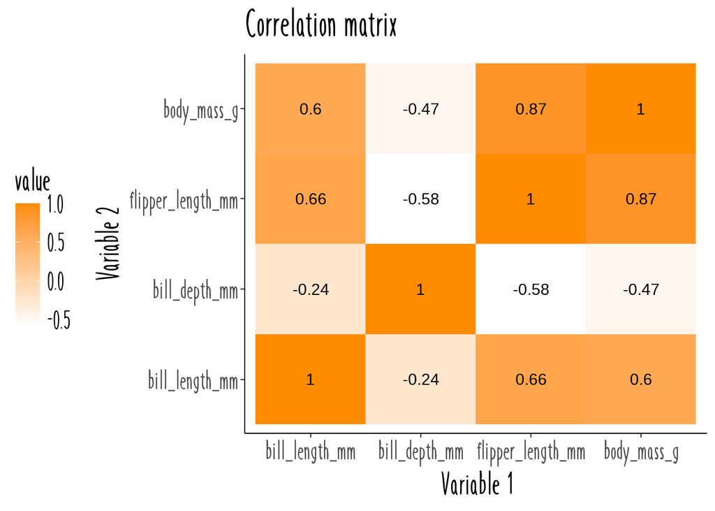

```r
melted_corr <- melt(corr)

ggplot(melted_corr, aes(x = Var1, y = Var2, fill = value)) +
  geom_tile() +
  geom_text(aes(label = value), color = "black", size = 8) +
  labs(x = "Variable 1", y = "Variable 2", title = "Correlation matrix") +
  theme_classic() +
  scale_fill_gradient(low = "white", high = "darkorange") +
  theme(text = element_text(family = "penguin", size = 40), legend.position = "left",
        plot.background = element_rect(fill = "white"), panel.background = element_rect(fill = "white"))
```

Congratulations!!

You just became a ggplot master and can start making your beauties even prettier! Have fun becoming a graphic designer ;)